# Wine Quality by Nicolas Veiga

### Volatile acidity versus citric acidity versus Quality

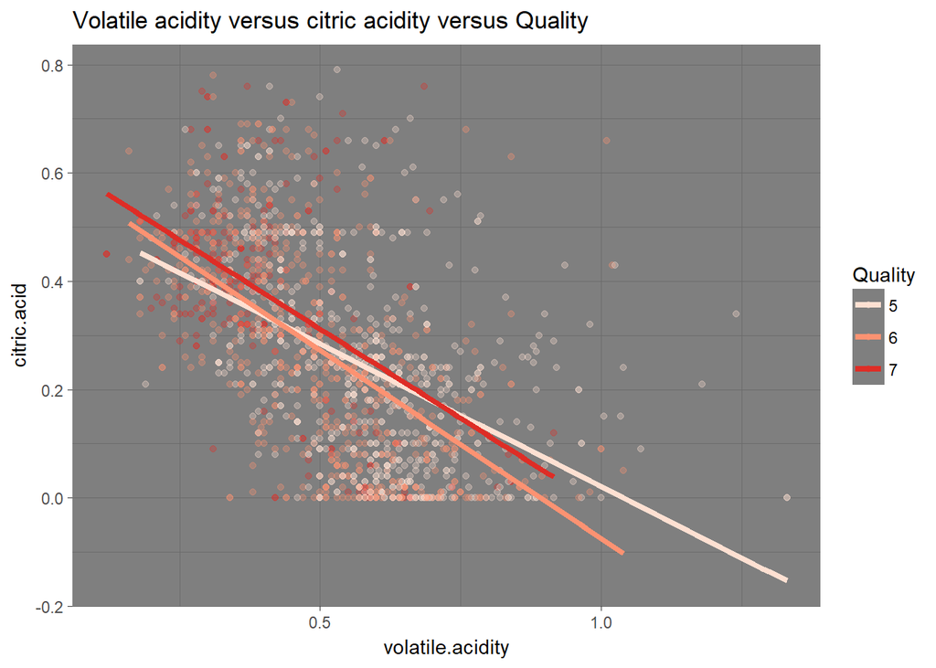

In this chart we can see better the differences between the wines when compared with the first chart of this section. The linear approximation does not help because they are grouped together and they do not take in consideration cluster of data points, that is the linear approximation is going to extend until it reaches all data points. We can notice that the wines with quality equals to 7 are better represented by low volatile acidity(<0.5) and high citric acid(>0.3), and that is not possible to observe with a linear approximation of the data points. Another conclusion is that wines with quality 5 have hight volatile acidity(>=0.6) and low citric acid values(<0.3). Now regarding quality 6, the wines can only be distinguished by volatile acidity, I would say that it is better represented by low to mid values(<0.6). All conclusion can also be taken from the graphs in bivariate plots section.

### Alcohol versus Citric acid versus Quality

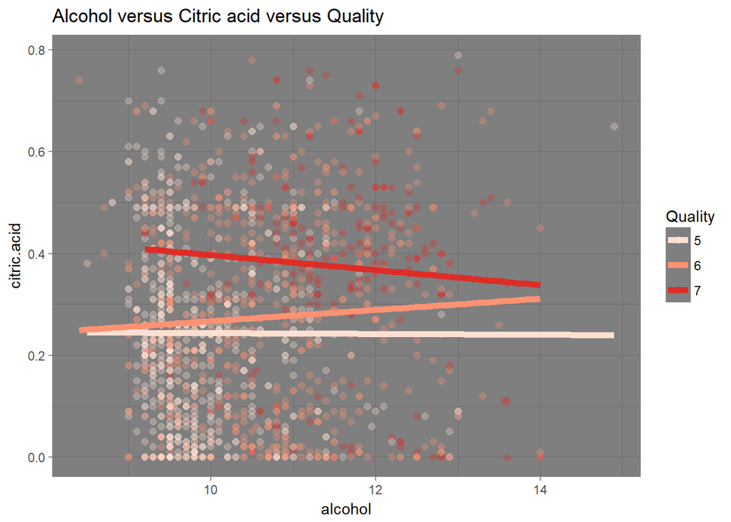

In this chart we can see some diferentiations between the categories, wines with quality 5 have low alcohol percentage(<10), wines with quality 6 are between 10% and 11.5% of alcohol and wines with quality 7 are better classified with alcohol higher than 11%. Now regarding citrict acid, qualities 5 and 6 are homogeneously spread in all y axes ranging from 0.0 to 0.7, now quality 7 is better grouped with high values of citric acid(>0.25).

### Alcohol versus Volatile acidity versus Quality

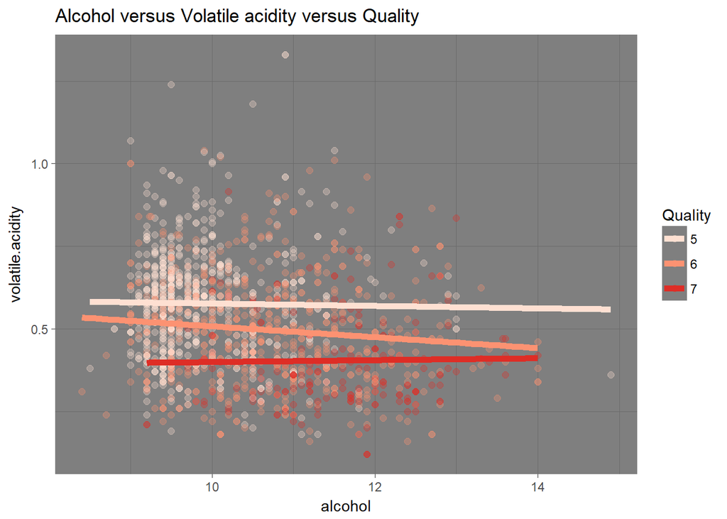

### Alcohol versus Density versus Quality

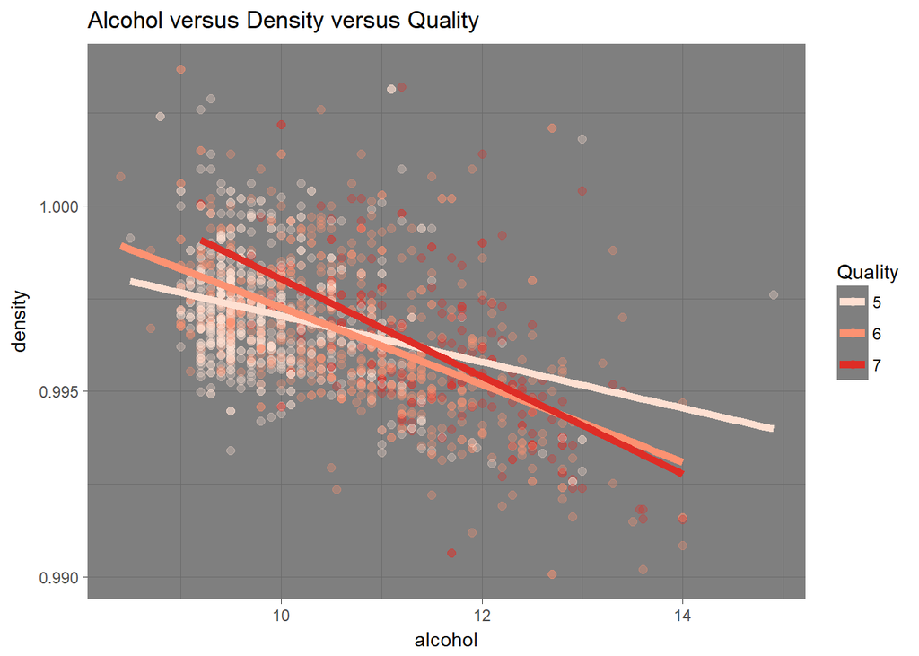

This graph gives a good delimitation for quality 5, but qualities 6 and 7 are interleaved in one cluster only. Quality 5 is well defined by alcohol below 10% and any density. Now for alcohol above 10%, we can not distinguish between quality 6 and 7.

# Multivariate Analysis

### Talk about some of the relationships you observed in this part of the investigation. Were there features that strengthened each other in terms of looking at your feature(s) of interest?

In this section we picked the attributes that presented any relationship with Quality and plot them together to see their pattern. Not surprise in there, we found that when plotting this variables together some clusters pop to our eyes. We can also notice that there is no clear boundary as stated in the bivariate section.

### Were there any interesting or surprising interactions between features?

No surprises, attributes like citric acidity is not very distinguishable between quality categories, we can notice that is harder to find clusters when this variable is used.

# Final Plots and Summary

### Plot One

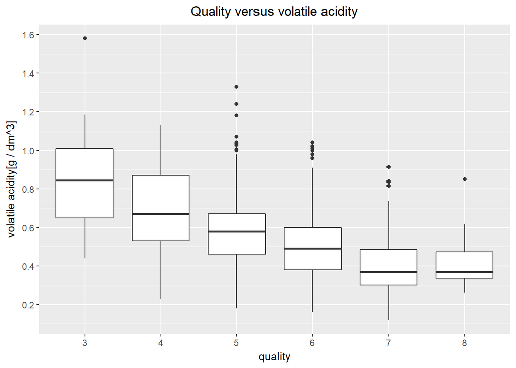

### Description One

This graph was choosen because it represents one of the variables that better distinguishes wine categories. The quality versus volatile.acidity is interresting because when we look to it we clearly see that wines with lower values are rated as better wines.

One thing to notice, when examing this graph and looking for qualities 5 and 6, the categories that have more data, we can see that a big portion of the data have similar values, more than 25%. That tell us that when plotting this variable agains others, we are going to see a large portion of the graph without a clear boundary between quality categories. That behavior happens in all the variables from this dataset.

### Plot Two

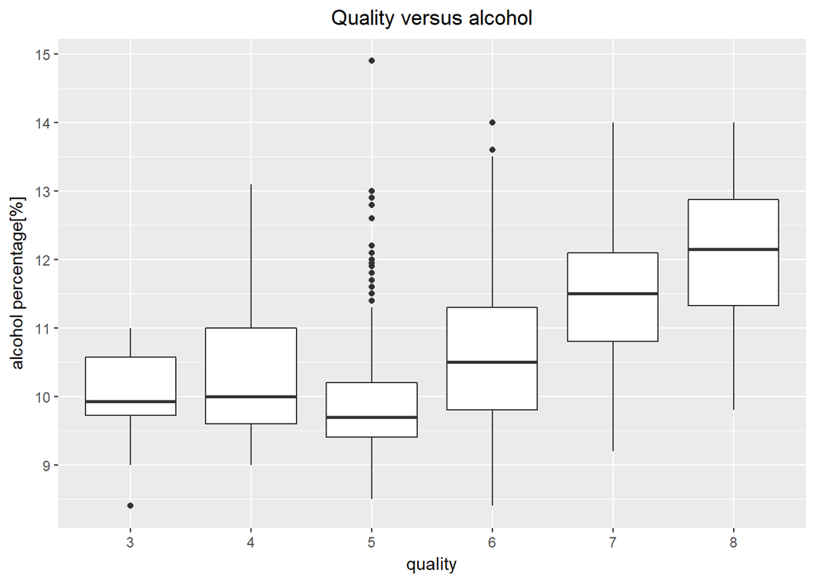

### Description Two

The graph was choosen because it is the variable that best categorize wines by their quality. Qualities 5 and 6 presents the lowest percentage of common values between this two categories, less than 25%, that means when using this variable against other, it is going to present a well defined boundary. The second feature is that it presents a pattern, we can see that wines with highest percentage of alcohol are classified as better wines.

### Plot Three

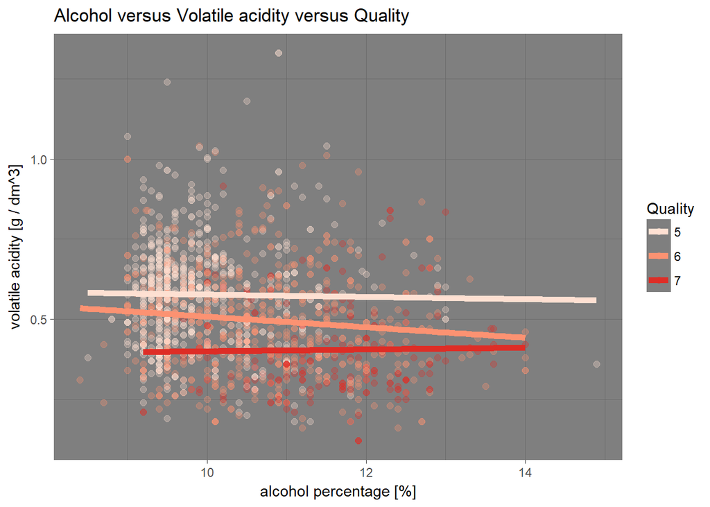

# Reflection

The wine quality dataset contains 1599 observations, each observation contains features from the wine and a score from 0 to 10 that indicates que quality of the wine. My work started looking at each variable independentily and after that the variable quality was explored agains the others variables in a attempt to classifie quality of the wine by its features.

The first detail about the exploration is that quality ranges from 3 to 8 and most of the wines are classified on 5, 6 and 7. When comparing quality with other features, we noticed that some features influence the quality of the wine and others no. An example of feature that influences is alcohol and one that does not influence is residual.sugar.

That conclusion was dranw by the crescent or decreasing pattern in the box plots graphs, where each level of quality is a category. We can also conclude from the box plot that there is no clear boundaries from one category to another.

In the multivariable section, we can see that there is no clear boundarie between the clusters, even thought it is possible to observe some regions where the data points are more condensed.

Most of the conclusions come from quality agains some other feature. From these graphs we can have an idea of what makes a good wine. From these graphs we conclude that a good wine has low volatily acidity, high citric acidity, high sulphates and high alcohol indices. Low and high are relative to each variable. Other variables were not so expresive in determining the quality of wines.

A good idea to improve the results would be to have a bigger dataset, this one is limited and in the end we excluded some quality categories because they had to fill samples. Also a model that is not linear could be used to categorize the data.